# Simulate epidemics and compute $R_0(t)$

```r
library(knitr)
library(BayesSEIR)
```

## Overview

This vignette illustrates the use of the BayesSEIR package to simulate epidemic data and calculate the basic reproductive numbers over epidemic time for three specification of the infectious period:

1. Exponentially distributed duration of the infectious period
2. Path-specific infectious periods according to the Weibull distribution
3. Infectious duration-dependent infectious periods using the gamma PDF

## Simulation Characteristics

For all examples, we simulate an epidemic over 100 days. We assume a population size of 1,000,000 individuals, with initial conditions specifying 1 infectious individual and the remaining 999,999 individuals as susceptible.

```r
# length of the epidemic
tau <- 100

# initial conditions of the population
N <- 1e6
I0 <- 1
E0 <- 0
S0 <- N - E0 - I0
```

We will also assume an intervention occurs on day 50, which causes a significant reduction in transmission. The intensity matrix $\mathbf{X}$ has two columns. The first is an intercept which provides constant baseline transmission. The second column indicates a change point occurs at time 50, after which transmission is constant. $\boldsymbol{\beta}$ must correspond with $\mathbf{X}$, having one element for each column. The first element of $\boldsymbol{\beta}$ specifies the baseline transmission rate. The second element provides the change in transmission after the intervention. Here, we specify the second element as negative which corresponds to a reduction in transmission after the intervention. Beta is always specified on the log scale, so that the inputs can be any real number value.

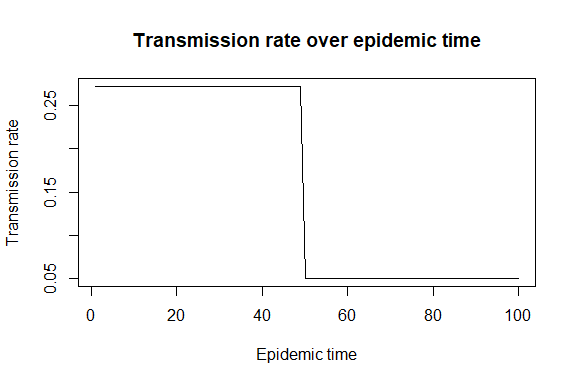

```r
# specify the design matrix so there is a change point in transmission at time 50
X <- cbind(1, c(rep(0, 49), rep(1, tau - 49)))

# beta specifies the transmission rate before the intervention and the change
# in transmission after the intervention
beta <- c(-1.3, -1.7)

plot(exp(X %*% beta), type = 'l', main = 'Transmission rate over epidemic time',
     xlab = 'Epidemic time', ylab = 'Transmission rate')
```

The last thing that will be kept constant for all three simulations is the specification of the latent period. We will assume the average length of time that an individual stays in the exposed compartment is 5 days, which corresponds to a rate of $1/5 = 0.2$.

```r
rateE <- 0.2
```

## Exponential infectious period

We will start by simulating under the assumption that the infectious period is exponentially distributed. Under this model, we must also specify the rate parameter associated with the infectious duration distribution. We assume individuals are infectious for 10 days, on average, which corresponds to a rate of $1/10 = 0.1$.

```r
rateI <- 0.1
```

First, let’s compute the reproductive number over time according to the parameters we have selected.

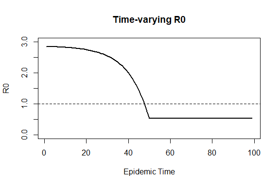

```r
# get reproductive number over time
expR0 <- getR0(infPeriodSpec = 'exp', beta, X, N,
                  infExpParams = list(rateI = rateI))

plot(expR0, main = 'Time-varying R0', xlab = 'Epidemic Time', ylab = 'R0',
     type = 'l', lwd = 2, ylim = c(0, 3))
abline(h = 1, lty = 2)
```

The reproductive number starts around 2.8. Due to the intervention, it starts to decrease. After the intervention, the reproductive number is flattened around 0.5. Knowing this is $R_0(t)$, we would expect transmission to continue to propagate until around day 50 and then it should decrease once the reproductive number is driven below 1.

Now, we can simulate a few epidemics, setting a seed for reproducibility:

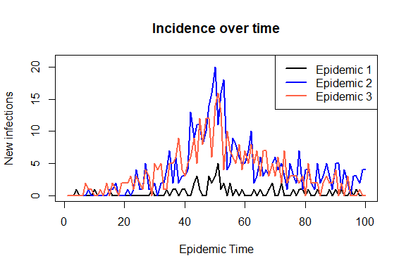

| Epidemic | Number Infected |
| --- | --- |
| 1 | 52 |
| 2 | 399 |
| 3 | 364 |

```r
# simulate using exponentially distributed infectious period
set.seed(123)
datExp1 <- simSEIR(S0, E0, I0, N, tau,
                  beta, X, rateE,
                  infPeriodSpec = 'exp',
                  infExpParams = list(rateI = rateI))

datExp2 <- simSEIR(S0, E0, I0, N, tau,
                  beta, X, rateE,
                  infPeriodSpec = 'exp',
                  infExpParams = list(rateI = rateI))

datExp3 <- simSEIR(S0, E0, I0, N, tau,
                  beta, X, rateE,
                  infPeriodSpec = 'exp',
                  infExpParams = list(rateI = rateI))

plot(datExp1$Istar, type = 'l', xlab = 'Epidemic Time', ylab = 'New infections',
     main = 'Incidence over time', lwd = 2, ylim = c(0, 21))
lines(datExp2$Istar, col = 'blue', lwd = 2)
lines(datExp3$Istar, col = 'tomato', lwd = 2)
legend('topright', paste0('Epidemic ', 1:3), col = c('black', 'blue', 'tomato'),
       lwd = 2)
```

## Path-specific infectious period

Next we will simulate epidemics under the assumption that the infectious period is Weibully distributed. Under this model, we must also specify the distribution as Weibull, the values of the associated shape and scale parameters, and the maximum length of time an individual is infectious. We will use a Weibull(7, 8) distribution, which corresponds to a mean infectious duration around 7.5 days and removal probabilities after 11 days around 1. We specify the maximum duration of the infectious period to be 14 days.

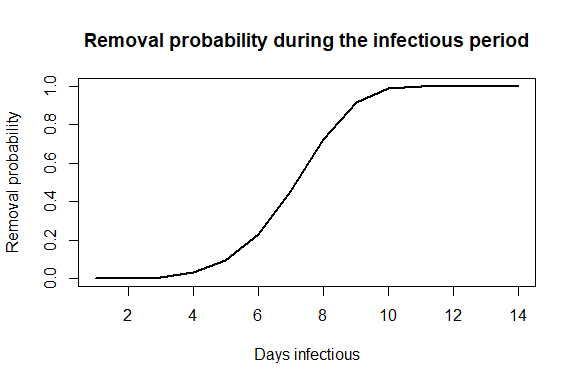

```r
dist <- 'weibull'
psParams <- list(shape = 7, scale = 8)
maxInf <- 14
plot(psProbVec(maxInf, dist, psParams),  type = 'l', lwd = 2,
     main = 'Removal probability during the infectious period',
     xlab = 'Days infectious', ylab = 'Removal probability')
```

Now, we can compute the reproductive number over time according to the parameters we have selected.

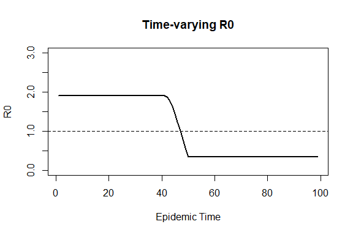

```r
# get reproductive number over time
psR0 <- getR0(infPeriodSpec = 'PS', beta, X, N,
                  infPSParams = list(dist = dist,
                                     psParams = psParams,
                                     maxInf = maxInf))

plot(psR0, main = 'Time-varying R0', xlab = 'Epidemic Time', ylab = 'R0',
     type = 'l', lwd = 2, ylim = c(0, 3))
abline(h = 1, lty = 2)
```

Now, we can simulate a few epidemics, setting a seed for reproducibility:

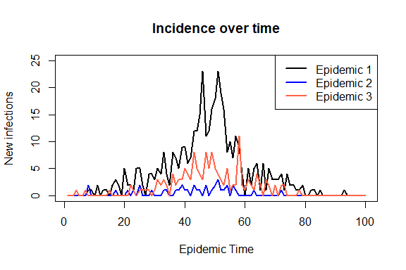

| Epidemic | Number Infected |
| --- | --- |
| 1 | 408 |
| 2 | 37 |
| 3 | 148 |

```r
# simulate using exponentially distributed infectious period
set.seed(123)
datPS1 <- simSEIR(S0, E0, I0, N, tau,
                  beta, X, rateE,
                  infPeriodSpec = 'PS',
                  infPSParams = list(dist = dist,
                                     psParams = psParams,
                                     maxInf = maxInf))

datPS2 <- simSEIR(S0, E0, I0, N, tau,
                  beta, X, rateE,
                  infPeriodSpec = 'PS',
                  infPSParams = list(dist = dist,
                                     psParams = psParams,
                                     maxInf = maxInf))

datPS3 <- simSEIR(S0, E0, I0, N, tau,
                  beta, X, rateE,
                  infPeriodSpec = 'PS',
                  infPSParams = list(dist = dist,
                                     psParams = psParams,
                                     maxInf = maxInf))

plot(datPS1$Istar, type = 'l', xlab = 'Epidemic Time', ylab = 'New infections',
     main = 'Incidence over time', lwd = 2, ylim = c(0, 25))
lines(datPS2$Istar, col = 'blue', lwd = 2)
lines(datPS3$Istar, col = 'tomato', lwd = 2)
legend('topright', paste0('Epidemic ', 1:3), col = c('black', 'blue', 'tomato'),
       lwd = 2)
```

## Infectious duration-dependent (IDD) transmission

Next we will simulate epidemics under the assumption that the infectious period is a fixed length, but that transmissibility varies over the duration of an individual’s infectious period. Under this model, we must also specify the functional form of the IDD curve, the parameters associatd with that curve, and the maximum length of time an individual is infectious. We will use a the gamma pdf with shape 4 and rate 1 to describe the IDD curve. This specifies that an individual’s transmission will peak on day 3 of the infectious period, and tail off by day 12. As in the path-specific example, we specify the maximum duration of the infectious period to be 14 days.

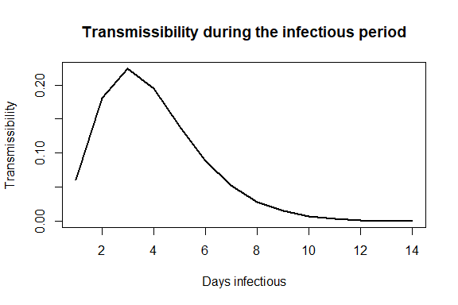

```r
iddFun <- dgammaIDD
iddParams <- list(shape = 4, rate = 1)
maxInf <- 14
plot(iddFun(1:maxInf, params = iddParams),  type = 'l', lwd = 2,
     main = 'Transmissibility during the infectious period',
     xlab = 'Days infectious', ylab = 'Transmissibility')
```

Due to the different parameterization of the IDD model, we must specify new value for the baseline transmissibility, $\beta_1$, in order to have transmission occur.

```r
beta <- c(0.95, -1.7)
```

Now, we can compute the reproductive number over time according to the parameters we have selected.

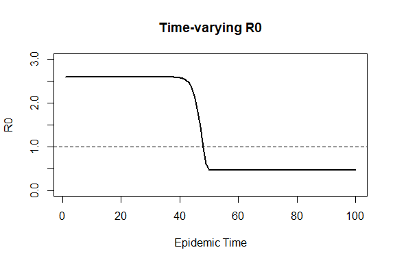

```r
# get reproductive number over time
iddR0 <- getR0(infPeriodSpec = 'IDD', beta, X, N,
                  infIDDParams = list(iddFun = iddFun,
                                     iddParams = iddParams,
                                     maxInf = maxInf))

plot(iddR0, main = 'Time-varying R0', xlab = 'Epidemic Time', ylab = 'R0',
     type = 'l', lwd = 2, ylim = c(0, 3))
abline(h = 1, lty = 2)
```

Now, we can simulate a few epidemics, setting a seed for reproducibility:

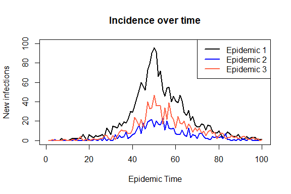

| Epidemic | Number Infected |
| --- | --- |
| 1 | 1971 |
| 2 | 478 |
| 3 | 957 |

```r
# simulate using exponentially distributed infectious period
set.seed(123)
datIDD1 <- simSEIR(S0, E0, I0, N, tau,
                  beta, X, rateE,
                  infPeriodSpec = 'IDD',
                  infIDDParams = list(iddFun = iddFun,
                                     iddParams = iddParams,
                                     maxInf = maxInf))

datIDD2 <- simSEIR(S0, E0, I0, N, tau,
                  beta, X, rateE,
                  infPeriodSpec = 'IDD',
                  infIDDParams = list(iddFun = iddFun,
                                     iddParams = iddParams,
                                     maxInf = maxInf))

datIDD3 <- simSEIR(S0, E0, I0, N, tau,
                  beta, X, rateE,
                  infPeriodSpec = 'IDD',
                  infIDDParams = list(iddFun = iddFun,
                                     iddParams = iddParams,
                                     maxInf = maxInf))

plot(datIDD1$Istar, type = 'l', xlab = 'Epidemic Time', ylab = 'New infections',
     main = 'Incidence over time', lwd = 2, ylim = c(0, 100))
lines(datIDD2$Istar, col = 'blue', lwd = 2)
lines(datIDD3$Istar, col = 'tomato', lwd = 2)
legend('topright', paste0('Epidemic ', 1:3), col = c('black', 'blue', 'tomato'),
       lwd = 2)
```